# Python 入门演示

## 简单的数学运算

整数相加，得到整数：

```python
2 + 2
```

```
4
```

浮点数相加，得到浮点数：

```python
2.0 + 2.5
```

```
4.5
```

整数和浮点数相加，得到浮点数：

```python
2 + 2.5
```

```
4.5
```

## 变量赋值

**Python**使用`<变量名>=<表达式>`的方式对变量进行赋值

```python
a = 0.2
```

## 字符串 String

字符串的生成，单引号与双引号是等价的：

```python
s = "hello world"
s
```

```
'hello world'
```

```python
s = 'hello world'
s
```

```
'hello world'
```

三引号用来输入包含多行文字的字符串：

```python
s = """hello
world"""
print s
```

```
hello
world
```

```python
s = '''hello
world'''
print s
```

```
hello
world
```

字符串的加法：

```python
s = "hello" + " world"
s
```

```
'hello world'
```

字符串索引：

```python
s[0]
```

```
'h'
```

```python
s[-1]
```

```
'd'
```

```python
s[0:5]
```

```
'hello'
```

字符串的分割：

```python
s = "hello world"
s.split()
```

```
['hello', 'world']
```

查看字符串的长度：

```python
len(s)
```

```
11
```

## 列表 List

Python用`[]`来生成列表

```python
a = [1, 2.0, 'hello', 5 + 1.0]
a
```

```
[1, 2.0, 'hello', 6.0]
```

列表加法：

```python
a + a
```

```
[1, 2.0, 'hello', 6.0, 1, 2.0, 'hello', 6.0]
```

列表索引：

```python
a[1]
```

```
2.0
```

列表长度：

```python
len(a)
```

```
4
```

向列表中添加元素：

```python
a.append("world")
a
```

```
[1, 2.0, 'hello', 6.0, 'world']
```

## 集合 Set

Python用{}来生成集合，集合中不含有相同元素。

```python
s = {2, 3, 4, 2}
s
```

```
{2, 3, 4}
```

集合的长度：

```python
len(s)
```

```
3
```

向集合中添加元素：

```python
s.add(1)
s
```

```
{1, 2, 3, 4}
```

集合的交：

```python
a = {1, 2, 3, 4}
b = {2, 3, 4, 5}
a & b
```

```
{2, 3, 4}
```

并：

```python
a | b
```

```
{1, 2, 3, 4, 5}
```

差：

```python
a - b
```

```
{1}
```

对称差：

```python
a ^ b
```

```
{1, 5}
```

## 字典 Dictionary

Python用`{key:value}`来生成Dictionary。

```python
d = {'dogs':5, 'cats':4}
d
```

```
{'cats': 4, 'dogs': 5}
```

字典的大小

```python
len(d)
```

```
2
```

查看字典某个键对应的值：

```python
d["dogs"]
```

```
5
```

修改键值：

```python
d["dogs"] = 2
d
```

```
{'cats': 4, 'dogs': 2}
```

插入键值：

```python
d["pigs"] = 7
d
```

```
{'cats': 4, 'dogs': 2, 'pigs': 7}
```

所有的键：

```python
d.keys()
```

```
['cats', 'dogs', 'pigs']
```

所有的值：

```python
d.values()
```

```
[4, 2, 7]
```

所有的键值对：

```python
d.items()
```

```
[('cats', 4), ('dogs', 2), ('pigs', 7)]
```

## 数组 Numpy Arrays

需要先导入需要的包，Numpy数组可以进行很多列表不能进行的运算。

```python
from numpy import array
a = array([1, 2, 3, 4])
a
```

```
array([1, 2, 3, 4])
```

加法：

```python
a + 2
```

```
array([3, 4, 5, 6])
```

```python
a + a
```

```
array([2, 4, 6, 8])
```

## 画图 Plot

Python提供了一个很像MATLAB的绘图接口。

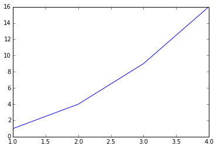

```python
%matplotlib inline
from matplotlib.pyplot import plot
plot(a, a**2)
```

## 循环 Loop

```python
line = '1 2 3 4 5'
fields = line.split()
fields
```

```
['1', '2', '3', '4', '5']
```

```python
total = 0
for field in fields:
    total += int(field)
total
```

```
15
```

Python中有一种叫做列表推导式(List comprehension)的用法：

```python
numbers = [int(field) for field in fields]
numbers
```

```
[1, 2, 3, 4, 5]
```

```python
sum(numbers)
```

```
15
```

写在一行：

```python
sum([int(field) for field in line.split()])
```

```
15
```

## 文件操作 File IO

```python
cd ~
```

```
C:\Users\lijin
```

写文件：

```python
f = open('data.txt', 'w')
f.write('1 2 3 4\n')
f.write('2 3 4 5\n')
f.close()
```

读文件：

```python
f = open('data.txt')
data = []
for line in f:
    data.append([int(field) for field in line.split()])
f.close()
data
```

```
[[1, 2, 3, 4], [2, 3, 4, 5]]
```

```python
for row in data:
    print row
```

```
[1, 2, 3, 4]
[2, 3, 4, 5]
```

删除文件：

```python
import os
os.remove('data.txt')
```

## 函数 Function

Python用关键词`def`来定义函数。

```python
def poly(x, a, b, c):
    y = a * x ** 2 + b * x + c
    return y

x = 1
poly(x, 1, 2, 3)
```

```
6
```

用Numpy数组做参数x：

```python
x = array([1, 2, 3])
poly(x, 1, 2, 3)
```

```
array([ 6, 11, 18])
```

可以在定义时指定参数的默认值：

```python
from numpy import arange

def poly(x, a = 1, b = 2, c = 3):
    y = a*x**2 + b*x + c
    return y

x = arange(10)
x
array([0, 1, 2, 3, 4, 5, 6, 7, 8, 9])
```

```
array([0, 1, 2, 3, 4, 5, 6, 7, 8, 9])
```

```python
poly(x)
```

```
array([  3,   6,  11,  18,  27,  38,  51,  66,  83, 102])
```

```python
poly(x, b = 1)
```

```
array([ 3,  5,  9, 15, 23, 33, 45, 59, 75, 93])
```

## 模块 Module

Python中使用`import`关键词来导入模块。

```python
import os
```

当前进程号：

```python
os.getpid()
```

```
127552
```

系统分隔符：

```python
os.sep
```

```
'\\'
```

## - 类 Class

用`class`来定义一个类。 `Person(object)`表示继承自`object`类； `__init__`函数用来初始化对象； `self`表示对象自身，类似于`C` `Java`里面`this`。

```python
class Person(object):
    def __init__(self, first, last, age):
        self.first = first
        self.last = last
        self.age = age
    def full_name(self):
        return self.first + ' ' + self.last
```

构建新对象：

```python
person = Person('Mertle', 'Sedgewick', 52)
```

调用对象的属性：

```python
person.first
```

```
'Mertle'
```

调用对象的方法：

```python
person.full_name()
```

```
'Mertle Sedgewick'
```

修改对象的属性：

```python
person.last = 'Smith'
```

添加新属性，d是之前定义的字典：

```python
person.critters = d
person.critters
```

```
{'cats': 4, 'dogs': 2, 'pigs': 7}
```

## 网络数据 Data from Web

```python
url = 'http://ichart.finance.yahoo.com/table.csv?s=GE&d=10&e=5&f=2013&g=d&a=0&b=2&c=1962&ignore=.csv'
```

处理后就相当于一个可读文件：

```python
import urllib2
ge_csv = urllib2.urlopen(url)
data = []
for line in ge_csv:
    data.append(line.split(','))
data[:4]
```

```
[['Date', 'Open', 'High', 'Low', 'Close', 'Volume', 'Adj Close\n'],
 ['2013-11-05', '26.32', '26.52', '26.26', '26.42', '24897500', '24.872115\n'],
 ['2013-11-04',
  '26.59',
  '26.59',
  '26.309999',
  '26.43',
  '28166100',
  '24.88153\n'],
 ['2013-11-01',
  '26.049999',
  '26.639999',
  '26.030001',
  '26.540001',
  '55634500',
  '24.985086\n']]
```

使用`pandas`处理数据：

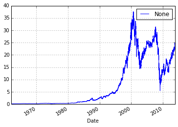

```python
ge_csv = urllib2.urlopen(url)
import pandas
ge = pandas.read_csv(ge_csv, index_col=0, parse_dates=True)
ge.plot(y='Adj Close')
```